# String Manipulation With stringr

Biostat 203B

Author

Dr. Hua Zhou @ UCLA

Published

February 6, 2024

# 1 String | r4ds chapter 14

We encounter text data often: sentiment analysis, electronic health records (doctor notes), twitter data, websites, …

## 1.1 stringr

- stringr package, by Hadley Wickham et al, provides utilities for handling strings.
- Included in tidyverse.

```r
library("tidyverse")
```

```r
# load htmlwidgets
library(htmlwidgets)
```

- Main functions in stringr:
  - `str_detect(string, pattern)`: Detect the presence or absence of a pattern in a string.
  - `str_locate(string, pattern)`: Locate the first position of a pattern and return a matrix with start and end.
  - `str_extract(string, pattern)`: Extract text corresponding to the first match.
  - `str_match(string, pattern)`: Extract matched groups from a string.
  - `str_split(string, pattern)`: Split string into pieces and returns a list of character vectors.
  - `str_replace(string, pattern, replacement)`: Replace the first matched pattern and returns a character vector.
- Variants with an `_all` suffix will match more than 1 occurrence of the pattern in a given string.
- Most functions are vectorized.

## 1.2 Basics

- Strings are enclosed by double quotes or single quotes:

```r
string1 <- "This is a string"
string2 <- 'If I want to include a "quote" inside a string, I use single quotes'
```

- Literal single or double quote:

```r
double_quote <- "\"" # or '"'
single_quote <- '\'' # or "'"
```

- Printed representation:

```r
x <- c("\"", "\\")
x
```

```
[1] "\"" "\\"
```

vs `cat` (how R views your string after all special characters have been parsed):

```r
cat(x)
```

```
" \
```

vs `writeLines()` (how R views your string after all special characters have been parsed):

```r
writeLines(x)
```

```
"
\
```

- Other special characters: `"\n"` (new line), `"\t"` (tab), … Check

```r
?"'"
```

for a complete list.

```r
cat("a\"b")
```

```
a"b
```

```r
cat("a\tb")
```

```
a   b
```

```r
cat("a\nb")
```

```
a
b
```

- Unicode

```r
x <- "\u00b5"
x
```

```
[1] "µ"
```

- Character vector (vector of strings):

```r
c("one", "two", "three")
```

```
[1] "one"   "two"   "three"
```

## 1.3 String length

- Length of a single string:

```r
str_length("R for data science")
```

```
[1] 18
```

- Lengths of a character vector:

```r
str_length(c("a", "R for data science", NA))
```

```
[1]  1 18 NA
```

## 1.4 Combining strings

- Combine two or more strings

```r
str_c("x", "y")
```

```
[1] "xy"
```

```r
str_c("x", "y", "z")
```

```
[1] "xyz"
```

- Separator:

```r
str_c("x", "y", sep = ", ")
```

```
[1] "x, y"
```

- `str_c()` is vectorised:

```r
str_c("prefix-", c("a", "b", "c"), "-suffix")
```

```
[1] "prefix-a-suffix" "prefix-b-suffix" "prefix-c-suffix"
```

- Objects of length 0 are silently dropped:

```r
name <- "Hadley"
time_of_day <- "morning"
birthday <- FALSE

str_c(
  "Good ",
  time_of_day,
  " ",
  name,
  if (birthday) " and HAPPY BIRTHDAY",
  "."
)
```

```
[1] "Good morning Hadley."
```

- Combine a vector of strings:

```r
# this is not collapsing
str_c(c("x", "y", "z"))
```

```
[1] "x" "y" "z"
```

```r
# collapse
str_c(c("x", "y", "z"), collapse = ", ")
```

```
[1] "x, y, z"
```

```r
# equivalently
str_flatten(c("x", "y", "z"), collapse = ", ")
```

```
[1] "x, y, z"
```

## 1.5 Subsetting strings

- By position:

```r
str_sub("Apple", 1, 3)
```

```
[1] "App"
```

```r
# vectorized
x <- c("Apple", "Banana", "Pear")
str_sub(x, 1, 3)
```

```
[1] "App" "Ban" "Pea"
```

- Negative numbers count backwards from end:

```r
str_sub(x, -3, -1)
```

```
[1] "ple" "ana" "ear"
```

- Out of range:

```r
str_sub("a", 1, 5)
```

```
[1] "a"
```

```r
str_sub("a", 2, 5)
```

```
[1] ""
```

- Assignment to a substring:

```r
str_sub(x, 1, 1) <- str_to_lower(str_sub(x, 1, 1))
x
```

```
[1] "apple"  "banana" "pear"
```

## 1.6 Matching patterns with regular expressions

- Match exact strings:

```r
x <- c("apple", "banana", "pear")
str_view(x, "an")
```

```
[2] │ b<an><an>a
```

- `.` matches any character apart from a newline:

```r
str_view(x, ".a.")
```

[output not shown]

- **Regex escapes live on top of regular string escapes, so there needs to be two levels of escapes.**  
  To match a literal `.`:

```r
# doesn't work because "a\.c" is treated as a regular expression
str_view(c("abc", "a.c", "bef"), "a\.c")
```

```
Error: '\.' is an unrecognized escape in character string (<text>:2:37)
```

```r
# regular expression needs double escape
str_view(c("abc", "a.c", "bef"), "a\\.c")
```

```
[2] │ <a.c>
```

To match a literal `\`:

```r
str_view("a\\b", "\\\\")
```

```
[1] │ a<\>b
```

[figure not shown]

## 1.7 Anchors

- `^` matches the start of the string:

```r
x <- c("apple", "banana", "pear")
str_view(x, "^a")
```

```
[1] │ <a>pple
```

- `$` matches the end of the string:

```r
str_view(x, "a$")
```

```
[2] │ banan<a>
```

- To force a regular expression to only match a complete string:

```r
x <- c("apple pie", "apple", "apple cake")
str_view(x, "^apple$")
```

```
[2] │ <apple>
```

## 1.8 Alternation

- `[abc]`: matches a, b, or c. Same as `(a|b|c)`.

```r
str_view(c("grey", "gray"), "gr(e|a)y")
```

```
[1] │ <grey>
[2] │ <gray>
```

```r
str_view(c("grey", "gray"), "gr[ea]y")
```

```
[1] │ <grey>
[2] │ <gray>
```

- `[^abc]`: matches anything except a, b, or c.
- `[a-z]`: matches any lower case letter.

## 1.9 Repetition

- `?`: 0 or 1  
  `+`: 1 or more  
  `*`: 0 or more
- Examples:

```r
x <- "1888 is the longest year in Roman numerals: MDCCCLXXXVIII"
# match either C or CC, being greedy here
str_view(x, "CC?")
```

```
[1] │ 1888 is the longest year in Roman numerals: MD<CC><C>LXXXVIII
```

```r
# greedy matches
str_view(x, "CC+")
```

```
[1] │ 1888 is the longest year in Roman numerals: MD<CCC>LXXXVIII
```

```r
# greedy matches
str_view(x, 'C[LX]+')
```

```
[1] │ 1888 is the longest year in Roman numerals: MDCC<CLXXX>VIII
```

- Specify number of matches:  
  `{n}`: exactly n  
  `{n,}`: n or more  
  `{,m}`: at most m  
  `{n,m}`: between n and m
- Examples:

```r
str_view(x, "C{2}")
```

```
[1] │ 1888 is the longest year in Roman numerals: MD<CC>CLXXXVIII
```

```r
# greedy matches
str_view(x, "C{2,}")
```

```
[1] │ 1888 is the longest year in Roman numerals: MD<CCC>LXXXVIII
```

```r
# greedy matches
str_view(x, "C{2,3}")
```

```
[1] │ 1888 is the longest year in Roman numerals: MD<CCC>LXXXVIII
```

- Greedy (default) vs lazy (put `?` after repetition):

```r
# lazy matches
str_view(x, 'C{2,3}?')
```

```
[1] │ 1888 is the longest year in Roman numerals: MD<CC>CLXXXVIII
```

```r
# lazy matches
str_view(x, 'C[LX]+?')
```

```
[1] │ 1888 is the longest year in Roman numerals: MDCC<CL>XXXVIII
```

- What went wrong here?

```r
text = "<div class='main'> <div> <a href='here.pdf'>Here!</a> </div> </div>"
str_extract(text, "<div>.*</div>")
```

```
[1] "<div> <a href='here.pdf'>Here!</a> </div> </div>"
```

If we add ? after a quantifier, the matching will be lazy (find the shortest possible match, not the longest).

```r
str_extract(text, "<div>.*?</div>")
```

```
[1] "<div> <a href='here.pdf'>Here!</a> </div>"
```

## 1.10 Grouping and backreference

- `fruit` is a character vector pre-defined in `stringr` package:

```r
fruit
```

```
 [1] "apple"             "apricot"           "avocado"
 [4] "banana"            "bell pepper"       "bilberry"
 [7] "blackberry"        "blackcurrant"      "blood orange"
[10] "blueberry"         "boysenberry"       "breadfruit"
[13] "canary melon"      "cantaloupe"        "cherimoya"
[16] "cherry"            "chili pepper"      "clementine"
[19] "cloudberry"        "coconut"           "cranberry"
[22] "cucumber"          "currant"           "damson"
[25] "date"              "dragonfruit"       "durian"
[28] "eggplant"          "elderberry"        "feijoa"
[31] "fig"               "goji berry"        "gooseberry"
[34] "grape"             "grapefruit"        "guava"
[37] "honeydew"          "huckleberry"       "jackfruit"
[40] "jambul"            "jujube"            "kiwi fruit"
[43] "kumquat"           "lemon"             "lime"
[46] "loquat"            "lychee"            "mandarine"
[49] "mango"             "mulberry"          "nectarine"
[52] "nut"               "olive"             "orange"
[55] "pamelo"            "papaya"            "passionfruit"
[58] "peach"             "pear"              "persimmon"
[61] "physalis"          "pineapple"         "plum"
[64] "pomegranate"       "pomelo"            "purple mangosteen"
[67] "quince"            "raisin"            "rambutan"
[70] "raspberry"         "redcurrant"        "rock melon"
[73] "salal berry"       "satsuma"           "star fruit"
[76] "strawberry"        "tamarillo"         "tangerine"
[79] "ugli fruit"        "watermelon"
```

- Parentheses define groups, which can be back-referenced as `\1`, `\2`, …

```r
# with match = TRUE, only show matched strings
str_view(fruit, "(..)\\1")
```

```
 [4] │ b<anan>a
[20] │ <coco>nut
[22] │ <cucu>mber
[41] │ <juju>be
[56] │ <papa>ya
[73] │ s<alal> berry
```

## 1.11 Detect matches

- `str_detect` return Booleans.

```r
x <- c("apple", "banana", "pear")
str_detect(x, "e")
```

```
[1]  TRUE FALSE  TRUE
```

- Vector `words` contains 980 commonly used words:

```r
length(words)
```

```
[1] 980
```

```r
head(words)
```

```
[1] "a"        "able"     "about"    "absolute" "accept"   "account"
```

- Examples:

```r
# How many common words start with t?
sum(str_detect(words, "^t"))
```

```
[1] 65
```

```r
# What proportion of common words end with a vowel?
mean(str_detect(words, "[aeiou]$"))
```

```
[1] 0.2765306
```

- Find words that end with `x`:

```r
words[str_detect(words, "x$")]
```

```
[1] "box" "sex" "six" "tax"
```

same as

```r
str_subset(words, "x$")
```

```
[1] "box" "sex" "six" "tax"
```

- Filter a data frame:

```r
df <- tibble(
  word = words,
  i = seq_along(word)
)
df %>%
  filter(str_detect(word, "x$"))
```

```
# A tibble: 4 × 2
  word      i
  <chr> <int>
1 box     108
2 sex     747
3 six     772
4 tax     841
```

- `str_count()` tells how many matches are found:

```r
x <- c("apple", "banana", "pear")
str_count(x, "a")
```

```
[1] 1 3 1
```

```r
# On average, how many vowels per word?
mean(str_count(words, "[aeiou]"))
```

```
[1] 1.991837
```

- Matches never overlap:

```r
str_count("abababa", "aba")
```

```
[1] 2
```

```r
str_view("abababa", "aba")
```

```
[1] │ <aba>b<aba>
```

- Mutate a data frame:

```r
df %>%
  mutate(
    vowels = str_count(word, "[aeiou]"),
    consonants = str_count(word, "[^aeiou]")
  )
```

```
# A tibble: 980 × 4
   word         i vowels consonants
   <chr>    <int>  <int>      <int>
 1 a            1      1          0
 2 able         2      2          2
 3 about        3      3          2
 4 absolute     4      4          4
 5 accept       5      2          4
 6 account      6      3          4
 7 achieve      7      4          3
 8 across       8      2          4
 9 act          9      1          2
10 active      10      3          3
# ℹ 970 more rows
```

## 1.12 Extract matches

- `sentences` is a collection of 720 phrases:

```r
length(sentences)
```

```
[1] 720
```

```r
head(sentences)
```

```
[1] "The birch canoe slid on the smooth planks."
[2] "Glue the sheet to the dark blue background."
[3] "It's easy to tell the depth of a well."
[4] "These days a chicken leg is a rare dish."
[5] "Rice is often served in round bowls."
[6] "The juice of lemons makes fine punch."
```

- Suppose we want to find all sentences that contain a colour.
- Create a collection of colours:

```r
(colours <- c("red", "orange", "yellow", "green", "blue", "purple"))
```

```
[1] "red"    "orange" "yellow" "green"  "blue"   "purple"
```

```r
(colour_match <- str_c(colours, collapse = "|"))
```

```
[1] "red|orange|yellow|green|blue|purple"
```

- Select the sentences that contain a colour, and then extract the colour to figure out which one it is:

```r
(has_colour <- str_subset(sentences, colour_match))
```

```
 [1] "Glue the sheet to the dark blue background."
 [2] "Two blue fish swam in the tank."
 [3] "The colt reared and threw the tall rider."
 [4] "The wide road shimmered in the hot sun."
 [5] "See the cat glaring at the scared mouse."
 [6] "A wisp of cloud hung in the blue air."
 [7] "Leaves turn brown and yellow in the fall."
 [8] "He ordered peach pie with ice cream."
 [9] "Pure bred poodles have curls."
[10] "The spot on the blotter was made by green ink."
[11] "Mud was spattered on the front of his white shirt."
[12] "The sofa cushion is red and of light weight."
[13] "The sky that morning was clear and bright blue."
[14] "Torn scraps littered the stone floor."
[15] "The doctor cured him with these pills."
```

[output cut: 42 more lines]

```r
(matches <- str_extract(has_colour, colour_match))
```

```
 [1] "blue"   "blue"   "red"    "red"    "red"    "blue"   "yellow" "red"
 [9] "red"    "green"  "red"    "red"    "blue"   "red"    "red"    "red"
[17] "red"    "blue"   "red"    "blue"   "red"    "green"  "red"    "red"
[25] "red"    "red"    "red"    "red"    "green"  "red"    "green"  "red"
[33] "purple" "green"  "red"    "red"    "red"    "red"    "red"    "blue"
[41] "red"    "blue"   "red"    "red"    "red"    "red"    "green"  "green"
[49] "green"  "red"    "red"    "yellow" "red"    "orange" "red"    "red"
[57] "red"
```

- `str_extract()` only extracts the first match.

```r
more <- sentences[str_count(sentences, colour_match) > 1]
str_view(more, colour_match)
```

```
[1] │ It is hard to erase <blue> or <red> ink.
[2] │ The <green> light in the brown box flicke<red>.
[3] │ The sky in the west is tinged with <orange> <red>.
```

- `str_extract_all()` extracts all matches:

```r
str_extract_all(more, colour_match)
```

```
[[1]]
[1] "blue" "red"

[[2]]
[1] "green" "red"

[[3]]
[1] "orange" "red"
```

- Setting `simplify = TRUE` in `str_extract_all()` will return a matrix with short matches expanded to the same length as the longest:

```r
str_extract_all(more, colour_match, simplify = TRUE)
```

```
     [,1]     [,2]
[1,] "blue"   "red"
[2,] "green"  "red"
[3,] "orange" "red"
```

```r
x <- c("a", "a b", "a b c")
str_extract_all(x, "[a-z]", simplify = TRUE)
```

```
     [,1] [,2] [,3]
[1,] "a"  ""   ""
[2,] "a"  "b"  ""
[3,] "a"  "b"  "c"
```

## 1.13 Grouped matches

- `str_extract()` gives us the complete match:

```r
# why "([^ ]+)" match a word?
noun <- "(a|the) ([^ ]+)"

has_noun <- sentences %>%
  str_subset(noun) %>%
  head(10)
has_noun %>%
  str_extract(noun)
```

```
 [1] "the smooth" "the sheet"  "the depth"  "a chicken"  "the parked"
 [6] "the sun"    "the huge"   "the ball"   "the woman"  "a helps"
```

- `str_match()` gives each individual component:

```r
has_noun %>%
  str_match(noun)
```

```
      [,1]         [,2]  [,3]
 [1,] "the smooth" "the" "smooth"
 [2,] "the sheet"  "the" "sheet"
 [3,] "the depth"  "the" "depth"
 [4,] "a chicken"  "a"   "chicken"
 [5,] "the parked" "the" "parked"
 [6,] "the sun"    "the" "sun"
 [7,] "the huge"   "the" "huge"
 [8,] "the ball"   "the" "ball"
 [9,] "the woman"  "the" "woman"
[10,] "a helps"    "a"   "helps"
```

- `tidyr::extract()` works with tibble:

```r
tibble(sentence = sentences) %>%
  tidyr::extract(
    sentence, c("article", "noun"), "(a|the) ([^ ]+)",
    remove = FALSE
  )
```

```
# A tibble: 720 × 3
   sentence                                    article noun
   <chr>                                       <chr>   <chr>
 1 The birch canoe slid on the smooth planks.  the     smooth
 2 Glue the sheet to the dark blue background. the     sheet
 3 It's easy to tell the depth of a well.      the     depth
 4 These days a chicken leg is a rare dish.    a       chicken
 5 Rice is often served in round bowls.        <NA>    <NA>
 6 The juice of lemons makes fine punch.       <NA>    <NA>
 7 The box was thrown beside the parked truck. the     parked
 8 The hogs were fed chopped corn and garbage. <NA>    <NA>
 9 Four hours of steady work faced us.         <NA>    <NA>
10 A large size in stockings is hard to sell.  <NA>    <NA>
# ℹ 710 more rows
```

## 1.14 Replacing matches

- Replace the first match:

```r
x <- c("apple", "pear", "banana")
str_replace(x, "[aeiou]", "-")
```

```
[1] "-pple"  "p-ar"   "b-nana"
```

- Replace all matches:

```r
str_replace_all(x, "[aeiou]", "-")
```

```
[1] "-ppl-"  "p--r"   "b-n-n-"
```

- Multiple replacement:

```r
x <- c("1 house", "2 cars", "3 people")
str_replace_all(x, c("1" = "one", "2" = "two", "3" = "three"))
```

```
[1] "one house"    "two cars"     "three people"
```

- Back-reference:

```r
# flip the order of the second and third words
sentences %>%
  str_replace("([^ ]+) ([^ ]+) ([^ ]+)", "\\1 \\3 \\2") %>%
  head(5)
```

```
[1] "The canoe birch slid on the smooth planks."
[2] "Glue sheet the to the dark blue background."
[3] "It's to easy tell the depth of a well."
[4] "These a days chicken leg is a rare dish."
[5] "Rice often is served in round bowls."
```

## 1.15 Splitting

- Split a string into pieces:

```r
sentences %>%
  head(5) %>%
  str_split(" ")
```

```
[[1]]
[1] "The"     "birch"   "canoe"   "slid"    "on"      "the"     "smooth"
[8] "planks."

[[2]]
[1] "Glue"        "the"         "sheet"       "to"          "the"
[6] "dark"        "blue"        "background."

[[3]]
[1] "It's"  "easy"  "to"    "tell"  "the"   "depth" "of"    "a"     "well."

[[4]]
[1] "These"   "days"    "a"       "chicken" "leg"     "is"      "a"
[8] "rare"    "dish."

[[5]]
[1] "Rice"   "is"     "often"  "served" "in"     "round"  "bowls."
```

- Use `simplify = TRUE` to return a matrix:

```r
sentences %>%
  head(5) %>%
  str_split(" ", simplify = TRUE)
```

```
     [,1]    [,2]    [,3]    [,4]      [,5]  [,6]    [,7]     [,8]
[1,] "The"   "birch" "canoe" "slid"    "on"  "the"   "smooth" "planks."
[2,] "Glue"  "the"   "sheet" "to"      "the" "dark"  "blue"   "background."
[3,] "It's"  "easy"  "to"    "tell"    "the" "depth" "of"     "a"
[4,] "These" "days"  "a"     "chicken" "leg" "is"    "a"      "rare"
[5,] "Rice"  "is"    "often" "served"  "in"  "round" "bowls." ""
     [,9]
[1,] ""
[2,] ""
[3,] "well."
[4,] "dish."
[5,] ""
```

# 2 More regular expressions

## 2.1 Character classes

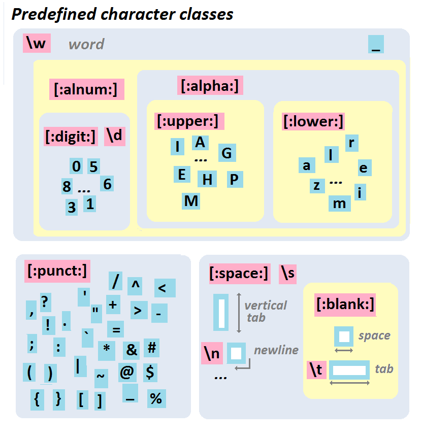

- A number of built-in convenience classes of characters:
  - `.`: Any character except new line `\n`.
  - `\s`: White space.
  - `\S`: Not white space.
  - `\d`: Digit (0-9).
  - `\D`: Not digit.
  - `\w`: Word (A-Z, a-z, 0-9, or _).
  - `\W`: Not word.
- Example: How to match a telephone number with the form (###) ###-####?

```r
# This produces error. Why?
text = c("apple", "(219) 733-8965", "(329) 293-8753")
str_detect(text, "(\d\d\d) \d\d\d-\d\d\d\d")
```

```
Error: '\d' is an unrecognized escape in character string (<text>:3:21)
```

```r
# This doesn't give the answer we want. Why?
text = c("apple", "(219) 733-8965", "(329) 293-8753")
str_detect(text, "(\\d\\d\\d) \\d\\d\\d-\\d\\d\\d\\d")
```

```
[1] FALSE FALSE FALSE
```

```r
# This should yield the desired answer
str_detect(text, "\\(\\d\\d\\d\\) \\d\\d\\d-\\d\\d\\d\\d")
```

```
[1] FALSE  TRUE  TRUE
```

## 2.2 Lists and ranges

- Lists and ranges:
  - `[abc]`: List (a or b or c)
  - `[^abc]`: Excluded list (not a or b or c)
  - `[a-q]`: Range lower case letter from a to q
  - `[A-Q]`: Range upper case letter from A to Q
  - `[0-7]`: Digit from 0 to 7

```r
text = c("apple", "(219) 733-8965", "(329) 293-8753")
str_replace_all(text, "[aeiou]", "") # strip all vowels
```

```
[1] "ppl"            "(219) 733-8965" "(329) 293-8753"
```

```r
str_replace_all(text, "[13579]", "*")
```

```
[1] "apple"          "(2**) ***-8*6*" "(*2*) 2**-8***"
```

```r
str_replace_all(text, "[1-5a-ep]", "*")
```

```
[1] "***l*"          "(**9) 7**-896*" "(**9) *9*-87**"
```

# 3 Teaser: how to validate email address using RegEx

https://r4ds.had.co.nz/strings.html#tools

# 4 Cheat sheet

[Posit cheat sheet](https://rstudio.github.io/cheatsheets/html/strings.html) is extremely helpful.